# MASH_Cours_13

Simon Gabay

03/02/2020

# Préparatifs

J’installe ma session de travail

```r
setwd("~/GitHub/Cours_DH_UniNE/Cours_13")
monDossier="~/GitHub/Cours_DH_UniNE/Cours_13"
```

```r
library(reshape2)
```

Première chose à faire: importer le corpus. Il s’agit d’un csv, donc nous utilisons la fonction `read.csv`

```r
theatre = "moliere_racine.tsv"
theatre <- read.csv(theatre, header=TRUE, sep = "\t", quote = '',fill = TRUE)
```

Je peux jeter un coup d’œil aux données brutes (on ne m’affiche que les première entrées de chaque colonne par commodité)

```r
str(theatre)
```

```
'data.frame':   724 obs. of  8 variables:
 $ auteur     : Factor w/ 5 levels "\"MOLIERE, Jean-Baptiste Pocquelin dit (1622-1673) CORNEILLE, Pierre (1606-1684) QUINAULT, Philippe (1635-1688)\"",..: 2 2 2 2 2 2 2 2 2 2 ...
 $ titre      : Factor w/ 44 levels "\"ALEXANDRE LE GRAND, TRAGÉDIE.\"",..: 2 2 2 2 2 2 2 2 2 2 ...
 $ date       : Factor w/ 24 levels "\"1650\"","\"1655\"",..: 12 12 12 12 12 12 12 12 12 12 ...
 $ genre      : Factor w/ 6 levels "\"Comédie galante\"",..: 3 3 3 3 3 3 3 3 3 3 ...
 $ inspiration: Factor w/ 11 levels "\"bible\"","\"féérie\"",..: 10 10 10 10 10 10 10 10 10 10 ...
 $ structure  : Factor w/ 5 levels "\"Cinq actes\"",..: 3 3 3 3 3 3 3 3 3 3 ...
 $ type       : Factor w/ 3 levels "\"mixte\"","\"prose\"",..: 3 3 3 3 3 3 3 3 3 3 ...
 $ texteLemmat: Factor w/ 724 levels "\" à  bande  de  point  de  Hongrie  appliquer  fort  proprement  sur  un  drap  de  couleur  de  olive  avec  "| __truncated__,..: 629 169 339 272 673 144 82 333 9 306 ...
```

Je peux aussi les regarder dans un tableau directement dans RStudio. On remarque que les colonnes ont des noms: “auteur”, “titre”…

```r
View(theatre)
```

Je peux sélectionner juste une colonne (ici “auteur”). Afin de ne pas tout afficher j’utilise `head()` pour ne montrer que les premières entrées:

```r
head(theatre$auteur)
```

```
[1] "MOLIERE, Jean-Baptiste Posquelin dit (1622-1673)"
[2] "MOLIERE, Jean-Baptiste Posquelin dit (1622-1673)"
[3] "MOLIERE, Jean-Baptiste Posquelin dit (1622-1673)"
[4] "MOLIERE, Jean-Baptiste Posquelin dit (1622-1673)"
[5] "MOLIERE, Jean-Baptiste Posquelin dit (1622-1673)"
[6] "MOLIERE, Jean-Baptiste Posquelin dit (1622-1673)"
5 Levels: "MOLIERE, Jean-Baptiste Pocquelin dit (1622-1673) CORNEILLE, Pierre (1606-1684) QUINAULT, Philippe (1635-1688)" ...
```

# Je construis et nettoye mon corpus

Toutes les colonnes sont des métadonnées, sauf `theatre$texteLemmat` qui contient des morceaux de pièces de 1000 mots afin de simplifier le travail. Il va falloir transformer le contenu de cette colonne en matrice terme-document (*Document Term Matrix*): je crée un tableau avec une colonne pour chaque mot de mon corpus, et un rang par texte de mon corpus.

|  | mot1 | mot2 | mot3 |
| --- | --- | --- | --- |
| Texte1 | 1 | 12 | 9 |
| Texte2 | 1 | 154 | 4 |

```r
#Je charge deux nouvelles librairies pour le _text mining_
if(!require("tm")){
  install.packages("tm")
  library("tm")
}
if(!require("tidytext")){
  install.packages("tidytext")
  library("tidytext")
}
corpus <- Corpus(VectorSource(theatre$texteLemmat), readerControl = list(language = "fr"))
corpus
```

```
<<SimpleCorpus>>
Metadata:  corpus specific: 1, document level (indexed): 0
Content:  documents: 724
```

```r
ncol(as.matrix(DocumentTermMatrix(corpus)))
```

```
[1] 8896
```

Théoriquement je devrais nettoyer mes données. En effet: “pas” et “Pas” ne sont pas les mêmes chaînes de caractères (il y a une majuscule dans le second), et peut-être même pas les mêmes mots (adverbe ou substantif?). Je dois donc au moins retirer les majuscules (avec `tolower()`), ou même lemmatiser (de préférence avec un outil spécifique, qui n’existe pas dans `R`). Ici, nous fournissons le texte déjà lemmatisé pour simplifier le travail

Comme notre objectif est d’avoir une approche thématique et conserver des mots potentiellement porteurs de sens: il faut donc retirer tous les mots les plus fréquents qui n’apportent, comme les les pronoms, les pronoms adverbiaux, les prépositions… Ces mots sont appelés des *stopwords* et une liste est fournie dans la fonction `stopwords()`

```r
stopwords("french")
```

```
  [1] "au"       "aux"      "avec"     "ce"       "ces"      "dans"     "de"       "des"
  [9] "du"       "elle"     "en"       "et"       "eux"      "il"       "je"       "la"
 [17] "le"       "leur"     "lui"      "ma"       "mais"     "me"       "même"     "mes"
 [25] "moi"      "mon"      "ne"       "nos"      "notre"    "nous"     "on"       "ou"
 [33] "par"      "pas"      "pour"     "qu"       "que"      "qui"      "sa"       "se"
 [41] "ses"      "son"      "sur"      "ta"       "te"       "tes"      "toi"      "ton"
 [49] "tu"       "un"       "une"      "vos"      "votre"    "vous"     "c"        "d"
 [57] "j"        "l"        "à"        "m"        "n"        "s"        "t"        "y"
 [65] "été"      "étée"     "étées"    "étés"     "étant"    "suis"     "es"       "est"
 [73] "sommes"   "êtes"     "sont"     "serai"    "seras"    "sera"     "serons"   "serez"
 [81] "seront"   "serais"   "serait"   "serions"  "seriez"   "seraient" "étais"    "était"
 [89] "étions"   "étiez"    "étaient"  "fus"      "fut"      "fûmes"    "fûtes"    "furent"
 [97] "sois"     "soit"     "soyons"   "soyez"    "soient"   "fusse"    "fusses"   "fût"
[105] "fussions" "fussiez"  "fussent"  "ayant"    "eu"       "eue"      "eues"     "eus"
[113] "ai"       "as"       "avons"    "avez"     "ont"      "aurai"    "auras"    "aura"
[121] "aurons"   "aurez"    "auront"   "aurais"   "aurait"   "aurions"  "auriez"   "auraient"
[129] "avais"    "avait"    "avions"   "aviez"    "avaient"  "eut"      "eûmes"    "eûtes"
[137] "eurent"   "aie"      "aies"     "ait"      "ayons"    "ayez"     "aient"    "eusse"
[145] "eusses"   "eût"      "eussions" "eussiez"  "eussent"  "ceci"     "cela"     "celà"
[153] "cet"      "cette"    "ici"      "ils"      "les"      "leurs"    "quel"     "quels"
[161] "quelle"   "quelles"  "sans"     "soi"
```

Il existe des listes alternatives en ligne, plus complètes: Je dois donc

```r
#Donner un nom au fichier que je télécharge
mesStops="stopwords-fr.csv"
#indiquer l'URL où se trouve le document à télécharger
stopword_enLigne = "https://raw.githubusercontent.com/stopwords-iso/stopwords-fr/master/stopwords-fr.txt"
#télécharger le fichier et l'enregistrer sous le nom que je viens de lui donner
download.file(stopword_enLigne,mesStops)
#Comme c'est un tableur, je le lis avec la fonction adéquat
stopword_enLigne = read.csv(stopword_enLigne, header=FALSE, stringsAsFactors=FALSE)[,]
#je jette un coup d'œil aux 10 premiers
head(stopword_enLigne,10)
```

```
 [1] "a"          "abord"      "absolument" "afin"       "ah"         "ai"         "aie"
 [8] "aient"      "aies"       "ailleurs"
```

Je vais utiliser mes listes de *stopwords* l’une après l’autre pour nettoyer mon corpus. Pour cela j’utilise la fonction `tm_map()` qui permet de modifier les corpora. Dans ce cas précise j’utilise `removeWords` avec chacune des deux listes.

Malheureusement cette commande `tm_map` fonctionne mal, et il est préférable de nettoyer le texte “à l’ancienne”

```r
#Je recharge mon corpus
corpus_clean <- tm_map(corpus_clean, PlainTextDocument)
```

```
transformation drops documents
```

````r
#je crée une fonction a deux paramètres: le corpus d'entrée et la liste des stopwords.
removeStopWords <- function(corpus_a_nettoyer, stopwords_a_retirer){
  # je fais une boucle pour retirer chaque mot de ```stopwords_a_retirer```
  for (word in stopwords_a_retirer){
    #J'utilise une fonction anonyme (_snonymous function_) à un paramètre qui utilise la fonction ```gsub``` qui remplace le mot de ```stopwords_a_retirer``` par rien.
    removeWord <- function(x) gsub(paste("(^|\\s)(",word,") ", sep="")," ",x)
    #on retire le mot
    corpus_a_nettoyer <- tm_map(corpus_a_nettoyer, removeWord)
  }
  #Je renvoie le résultat
  return(corpus_a_nettoyer)
}
#Je passe mon ```corpus_clean``` comme ```corpus_a_nettoyer``` et mes ```stopword_enLigne``` comme ```stopwords_a_retirer```.
corpus_clean <- removeStopWords(corpus_clean, stopword_enLigne)
````

[output not shown]

S’il reste des mots qui ne me plaisent pas, je peux continuer de les retirer en les mettant dans un vecteur

```r
stopWords <- c( "à_le", "de_le", "-être", "faire", "falloir", "savoir", "pouvoir", "devoir", "devoir", "voir", "vouloir")
corpus_clean <- tm_map(corpus_clean, removeWords, stopWords)
```

```
transformation drops documents
```

```r
inspect(corpus_clean[6])
```

```
<<SimpleCorpus>>
Metadata:  corpus specific: 1, document level (indexed): 0
Content:  documents: 1

[1] "  frayeur   âme blesser  moindre choc   entendre     horreur    pensée   jamais  consoler  coup   menacer   laurier   couronne  vainqueur  part     honneur suprême valoir    coûter  tendresse   cœur    moment trembler    aimer       feu   augmenter   marquer  œil  cœur  enflammer    avouer  cho…
```

Je fais de nouveau une matrice “terme/document” (DTM, *Document-term matrix*). On se rappelle qu’il s’agit de créer une matrice (un tableau) avec une colonne pour chaque mot de mon corpus, et un rang par texte de mon corpus.

|  | mot1 | mot2 | mot3 |
| --- | --- | --- | --- |
| Texte1 | 1 | 12 | 9 |
| Texte2 | 1 | 154 | 4 |

```r
dtm <- DocumentTermMatrix(corpus_clean)
rownames(dtm) <- theatre$genre
```

Je peux désormais observer la fréquence des mots: je retrouve la loi de Zipf dans la distribution de mes données

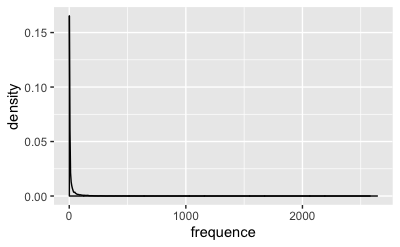

````r
freq <- as.data.frame(colSums(as.matrix(dtm)))
colnames(freq) <- c("frequence")
#Comme je vais dessiner un graph, j'ai besoin d'une nouvelle librairie: ```ggplot2```
if (!require("ggplot2")){
  install.packages("ggplot2")
  library("ggplot2")
}
#Je dessine mon graph
ggplot(freq, aes(x=frequence)) + geom_density()
````

```r
#Je retire tous les mots qui apparaissent entre 0 et 400 fois (on peut remplacer 400 par 100, ou même 10 si le corpus est trop gros)
motsPeuFrequents <- findFreqTerms(dtm, 0, 400)
length(motsPeuFrequents)
```

```
[1] 8551
```

```r
head(motsPeuFrequents,50)
```

```
 [1] "admirer"     "agir"        "aile"        "aise"        "alcmène"     "allure"      "amoureux"
 [8] "amphitryon"  "ardeur"      "arrêter"     "artifice"    "asseoir"     "aventure"    "aviser"
[15] "badinage"    "beauté"      "besoin"      "bout"        "béotique"    "bête"        "cause"
[22] "censeur"     "cesse"       "chaise"      "chaleur"     "changement"  "charmant"    "cheval"
[29] "chérir"      "commander"   "comprendre"  "cruel"       "cygne"       "daigner"     "dame"
[36] "decorum"     "descendre"   "destin"      "devenir"     "deviner"     "divinité"    "don"
[43] "doucement"   "douceur"     "doute"       "doux"        "déguisement" "délicieux"   "désirer"
[50] "emploi"
```

Je peux aussi compter et afficher les mots les plus fréquents, par exemple avec plus de 400 occurrences

```r
motsTresFrequents <- findFreqTerms(dtm, 401, Inf)
length(motsTresFrequents)
```

```
[1] 65
```

```r
head(motsTresFrequents,50)
```

```
 [1] "aimer"     "aller"     "amour"     "attendre"  "chose"     "ciel"      "connaître" "coup"
 [9] "croire"    "cœur"      "dieu"      "donner"    "foi"       "fort"      "gloire"    "homme"
[17] "jamais"    "jour"      "mal"       "mettre"    "oui"       "passer"    "penser"    "plaire"
[25] "point"     "prendre"   "seigneur"  "soin"      "sortir"    "trouver"   "venir"     "âme"
[33] "œil"       "affaire"   "esprit"    "grand"     "honneur"   "madame"    "monde"     "monsieur"
[41] "mort"      "nom"       "porter"    "raison"    "temps"     "chercher"  "entendre"  "lieu"
[49] "main"      "perdre"
```

````r
#Je crée une fonction ```grandMenage```
grandMenage <- function(corpus_a_nettoyer, mots_peu_importants){
  #Afin de simplifier le travail (de mon ordinateur), je vais rassembler les mots à retirer en groupe 500 tokens, que je vais traiter séparément.
    chunk <- 500
    #Je compte le nombre de mots à retirer
    n <- length(mots_peu_importants)
    #Je compte les groupes de 500 (ici 17.05), j'arrondis au plus petit entier supérieur (ici 18)
    r <- rep(1:ceiling(n/chunk),each=chunk)[1:n]
    #Je constitue mes lots sur la base du décompte précédemment mentionné
    d <- split(mots_peu_importants,r)
    #Je fais une boucle: pour retirer les mots du corpus, morceau par morceau
    for (i in 1:length(d)) {
        corpus_a_nettoyer <- tm_map(corpus_a_nettoyer, removeWords, c(paste(d[[i]])))
    }
    #Je renvoie un résultat
    return(corpus_a_nettoyer)
}
# J'utilise ma fonction avec ```corpus_clean``` comme ```corpus_a_nettoyer``` et ```motsPeuFrequents``` comme ```mots_peu_importants```
corpus_clean <- grandMenage(corpus_clean, motsPeuFrequents)
````

[output not shown]

Je redéfinis ma matrice à partir de mon nouveau corpus

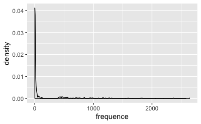

```r
dtm <- DocumentTermMatrix(corpus_clean)
rownames(dtm) <- theatre$genre
freq <- as.data.frame(colSums(as.matrix(dtm)))
colnames(freq) <- c("frequence")
#Je fais un petit graph
ggplot(freq, aes(x=frequence)) + geom_density()
```

Je nettoye un peu ma DTM et pour éliminer les rangs vides

```r
rowTotals <- apply(dtm , 1, sum)      #Find the sum of words in each Document
dtm_clean   <- dtm[rowTotals> 0, ]    #remove all docs without words
```

Avec mon corpus bien propre, je peux désormais faire une allocation de Dirichlet latente ( *Latent Dirichlet allocation*, LDA). On peut faire varier le nombre de thèmes ( *topic*) en modifiant la variable `k`: nous allons tenter de définir 2, puis 3 sujets. Ce chiffre nous paraît optimal, car nous travaillons sur un petit corpus de quelques genres seulement (et ce sont ces genres qui nous intéressent).

Le *LDA* est modèle génératif probabiliste permettant d’expliquer des ensembles d’observations, par le moyen de groupes non observés, eux-mêmes définis par des similarités de données. C’est un système de classification non supervisé

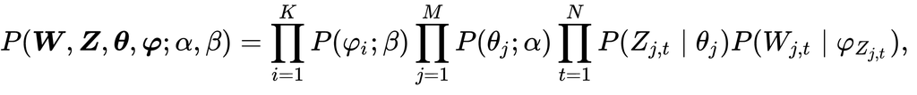

Source: [wikipedia](https://en.wikipedia.org/wiki/Latent_Dirichlet_allocation)

Dans ce graph: * M est le nombre de documents (corpus) * N est le nombre de mots (document) * W est un mot observé

La partie *latente* (cachée): * Z est un *topic* attribué à un *w* * θ est le mélange des *topics* à l’échelle du document

Deux paramètres pour la distribution * α est la distribution par document. Si sa valeur est élevée, le document tend à contenir plusieurs *topics*, si la valeur est faible le nombre de *topics* est limité * β est la distribution par *topic*. Si sa valeur est élevée, un même mot se retrouve dans plusieurs *topics* (qui se ressemblent donc), si la valeur est faible les similarités entre les *topics* est faible

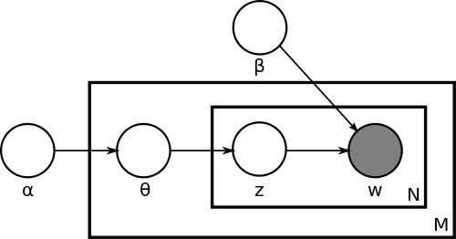

Source: [wikipedia](https://commons.wikimedia.org/wiki/File:Latent_Dirichlet_allocation.svg)

Le résultat produit est une matrice avec pour chaque mot la probabiltié qu’il appartienne à un des différents *topics*

```r
#J'installe une nouvelle librairie pour le _topic modeling_
if(!require("topicmodels")){
  install.packages("topicmodels")
  library("topicmodels")
}
#Je vais partir sur une classification en deux _topics_
k = 2
lda_2 <- LDA(dtm_clean, k= k, control = list(seed = 1234))
##Je tente avec trois, pour voir…
lda_3 <- LDA(dtm_clean, k= k+1, control = list(alpha = 0.1))
```

Les paramètres de Gibbs permettent une sophistication du système précédent. C’est une probabilité conditionnelle qui s’appuie, pour calculer le β d’un mot, sur le β des mots voisins. Pour ce faire nous devons déterminer: 1. À quel point un document aime un *topic* 2. À quel pount un *topic* aime un mot

Un document:

| Voiture | Autoroute | Musique | Vélo | Vacances |
| --- | --- | --- | --- | --- |
| 1 | ?? | 2 | 1 | 3 |

Sachant que le décompte est le suivant

|  | topic 1 | topic 2 | topic 3 |
| --- | --- | --- | --- |
| Voiture | 34 | 49 | 75 |
| Autoroute | 150 | 50 | 70 |
| Musique | 34 | 4 | 170 |
| Vélo | 543 | 2 | 150 |
| Vacances | 23 | 70 | 563 |

Le *topic* 1 est le plus représenté dans le document, et *Autoroute* est déjà surreprésenté dans le décompte, donc on *update* le tout

| Voiture | Autoroute | Musique | Vélo | Vacances |
| --- | --- | --- | --- | --- |
| 1 | **1** | 2 | 1 | 3 |

|  | topic 1 | topic 2 | topic 3 |
| --- | --- | --- | --- |
| Voiture | 34 | 49 | 75 |
| Autoroute | **151** | 50 | 70 |
| Musique | 34 | 4 | 170 |
| Vélo | 543 | 2 | 150 |
| Vacances | 23 | 70 | 563 |

Combien un document aime le topic, combien un *topic* aime un mot.

```r
## Set parameters for Gibbs sampling
#Le modèle va tourner 2000 fois avant de commencer à enregistrer les résultats
burnin <- 2000
#Après cela il va encore tourner 2000 fois
iter <- 2000
# Il ne va enregistrer le résultat que tous les 500 itérations
thin <- 500
#seed et nstart pour la reproductibilité
SEED=c(1, 2, 3, 4, 5)
seed <-SEED
nstart <- 5
#Seul meilleur modèle est utilisé
best <- TRUE
#2 topics
lda_gibbs_2 <- LDA(dtm_clean, k, method="Gibbs", control=list(nstart=nstart, seed=seed, best=best, burnin=burnin, iter=iter, thin=thin))
#3 topics
lda_gibbs_3 <- LDA(dtm_clean, k+1, method="Gibbs", control=list(nstart=nstart, seed=seed, best=best, burnin=burnin, iter=iter, thin=thin))
```

Je peux désormais voir les premiers résultats pour chacun des modèles

```r
"LDA 2"
```

```
[1] "LDA 2"
```

```r
termsTopic <- as.data.frame(terms(lda_2,10))
head(termsTopic,11)
```

```
    Topic 1  Topic 2
1     venir    point
2  monsieur    aller
3     point     cœur
4   prendre    amour
5     aller   donner
6    madame monsieur
7     homme   croire
8    jamais    chose
9       œil   mettre
10     père      oui
```

```r
"LDA 3"
```

```
[1] "LDA 3"
```

```r
termsTopic <- as.data.frame(terms(lda_3,10))
head(termsTopic,11)
```

```
    Topic 1  Topic 2 Topic 3
1  seigneur monsieur    cœur
2     aller    point   amour
3      fils    aller   aimer
4      dieu    chose   point
5       roi    venir     œil
6    madame      oui     âme
7     point   donner  croire
8      sang  prendre   venir
9       œil    homme  madame
10    venir     fort   aller
```

```r
"LDA GIBBS 2"
```

```
[1] "LDA GIBBS 2"
```

```r
termsTopic <- as.data.frame(terms(lda_gibbs_2,10))
head(termsTopic,11)
```

```
    Topic 1  Topic 2
1     point     cœur
2  monsieur   madame
3     aller    amour
4     venir      œil
5    donner    aimer
6   prendre seigneur
7       oui     dieu
8     chose     ciel
9   trouver     jour
10    homme   croire
```

```r
"LDA GIBBS 3"
```

```
[1] "LDA GIBBS 3"
```

```r
termsTopic <- as.data.frame(terms(lda_gibbs_3,10))
head(termsTopic,11)
```

```
   Topic 1  Topic 2  Topic 3
1    point monsieur seigneur
2     cœur    aller     dieu
3   madame      oui      œil
4   croire   donner     fils
5    venir    chose    aller
6    aimer  prendre     main
7    amour    homme     jour
8   jamais  trouver      roi
9      âme     fort     père
10   grand    venir attendre
```

Nous allons utiliser `lda_gibbs_2` et construire une matrice avec les β des tokens (pour les ɣ, et donc des probabilités par document, on aurait mis `matrix = "gamma"`). Chaque token est répété deux fois, avec une probabilité pour chaque *topic*

```r
topics <- tidy(lda_gibbs_2, matrix = "beta")
topics
```

| topic | term | beta |
| --- | --- | --- |
| 1 | aimer | 3.712724e-06 |
| 2 | aimer | 3.995168e-02 |
| 1 | alcmène | 5.977486e-04 |
| 2 | alcmène | 8.114439e-04 |
| 1 | aller | 6.497639e-02 |
| 2 | aller | 2.258458e-02 |
| 1 | amour | 3.712724e-06 |
| 2 | amour | 4.288903e-02 |
| 1 | attendre | 3.712724e-06 |
| 2 | attendre | 2.045500e-02 |

[output cut: 838 more lines]

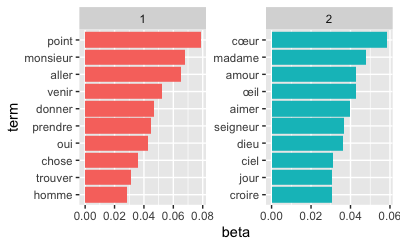

```r
#Je vais encore solliciter une nouvelle librairie
if (!require("dplyr")){
   install.packages("dplyr")
  library("dplyr")
}
#Je récupère mes mots
top_terms <- topics %>%
  group_by(topic) %>%
  top_n(10, beta) %>%
  ungroup()  %>%
  arrange(topic, -beta)
#Je fais un graph
top_terms %>%
  mutate(term = reorder_within(term, beta, topic)) %>%
  ggplot(aes(term, beta, fill = factor(topic))) +
  geom_col(show.legend = FALSE) +
  facet_wrap(~ topic, scales = "free") +
  coord_flip() +
  scale_x_reordered()
```

`Je vais désormais associer chaque mot à l’un des 5 genres possibles, pour déterminer auquel mes tokens sont rattachés, et découvrir (potentiellement quel genre se cacher derrière quel *topic*

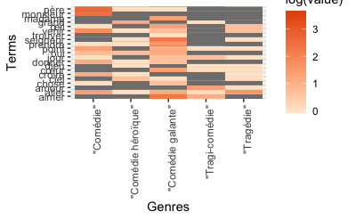

```r
if (!require("reshape2")){
  install.packages("reshape2")
  library("reshape2")
}
df <- melt(as.matrix(dtm_clean))
df <- df[df$Terms %in% findFreqTerms(dtm_clean, lowfreq = 800), ]
ggplot(df, aes(as.factor(Docs), Terms, fill=log(value))) + geom_tile() + xlab("Genres") + scale_fill_continuous(low="#FEE6CE", high="#E6550D") + theme(axis.text.x = element_text(angle=90, hjust=1))
```

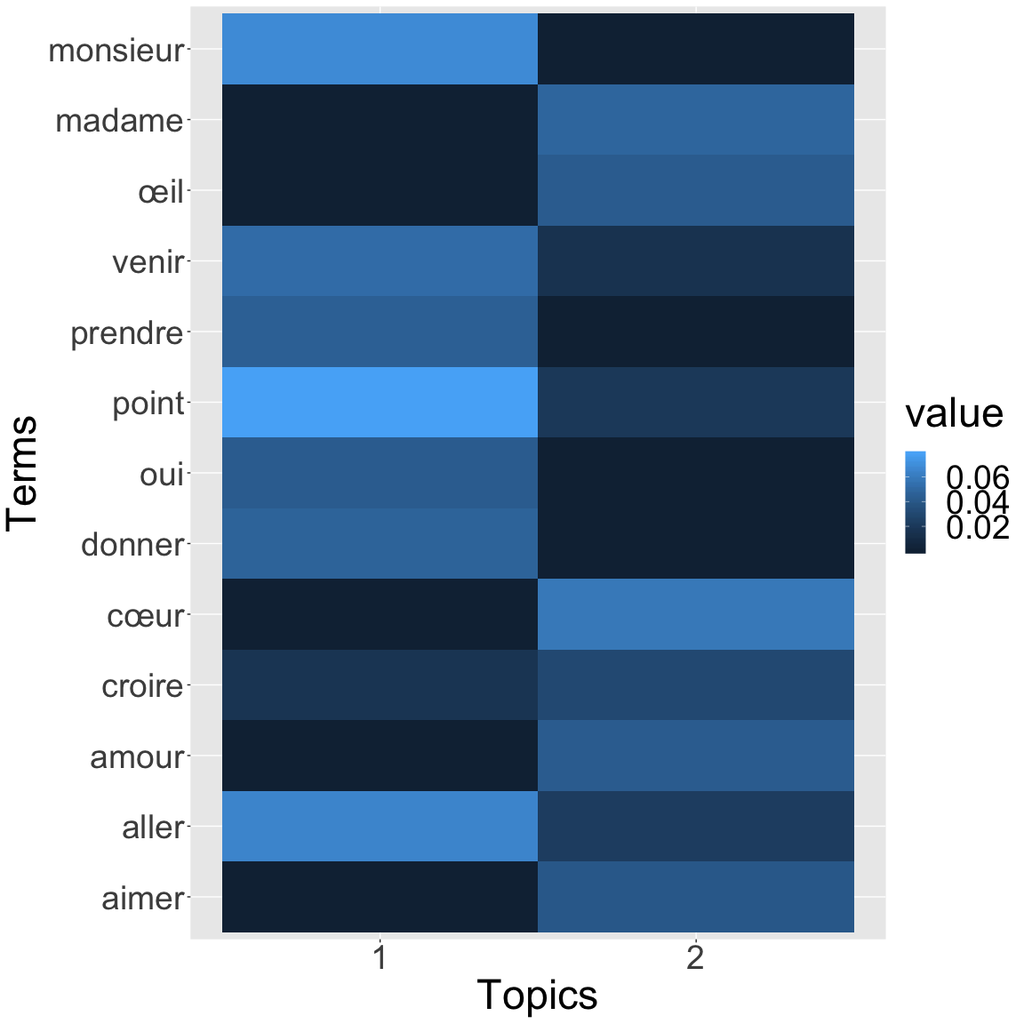

```r
tt <- posterior(lda_gibbs_2)$terms
melted = melt(tt[,findFreqTerms(dtm_clean, 1000,10000)])
colnames(melted) <- c("Topics", "Terms", "value")
melted$Topics <- as.factor(melted$Topics)
ggplot(data = melted, aes(x=Topics, y=Terms, fill=value)) +
  geom_tile() + theme(text = element_text(size=35))
```

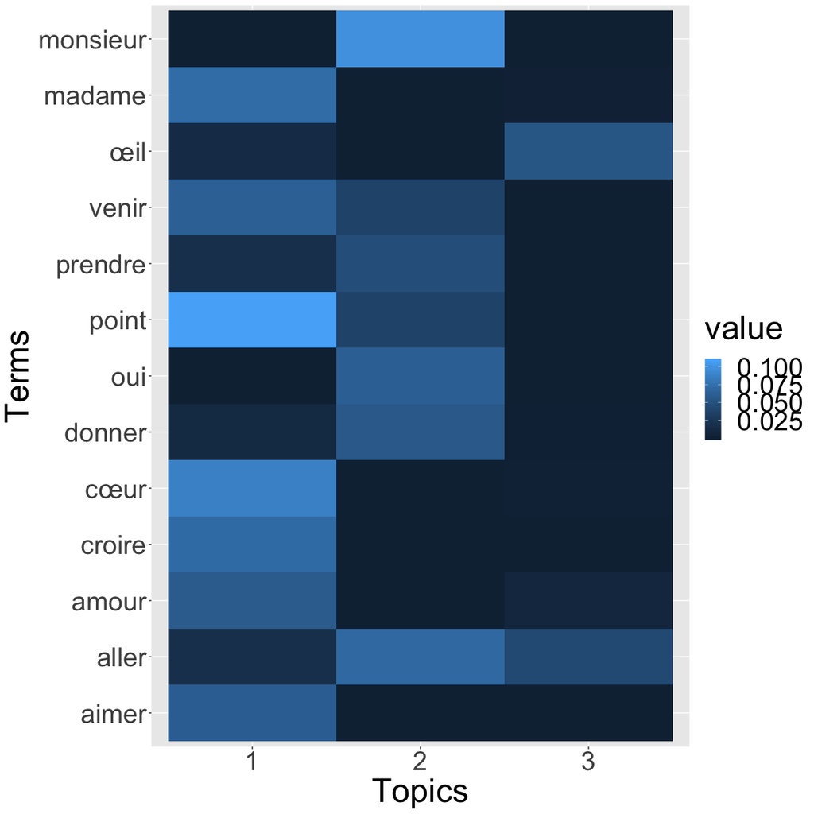

```r
tt <- posterior(lda_gibbs_3)$terms
melted = melt(tt[,findFreqTerms(dtm_clean, 1000,10000)])
colnames(melted) <- c("Topics", "Terms", "value")
melted$Topics <- as.factor(melted$Topics)
ggplot(data = melted, aes(x=Topics, y=Terms, fill=value)) +
  geom_tile() + theme(text = element_text(size=35))
```

```r
DocumentTopicProbabilities <- as.data.frame(lda_gibbs_2@gamma)
rownames(DocumentTopicProbabilities) <- rownames(corpus_clean)
head(DocumentTopicProbabilities)
```

```
         V1        V2
1 0.4786325 0.5213675
2 0.5083333 0.4916667
3 0.5433071 0.4566929
4 0.5619835 0.4380165
5 0.5357143 0.4642857
6 0.4545455 0.5454545
```

### Wordclouds

Nous allons désormais faire des *word clouds*. Pour cela appelons (installons?) les libraries suivantes:

```r
if (!require("wordcloud")){
   install.packages("wordcloud")
  library("wordcloud")
}
if (!require("RColorBrewer")){
   install.packages("RColorBrewer")
  library("RColorBrewer")
}
if (!require("wordcloud2")){
   install.packages("wordcloud2")
  library("wordcloud2")
}
```

je récupère les mots et je les associe à leur 𝛃

```r
tm <- posterior(lda_gibbs_2)$terms
data = data.frame(colnames(tm))
head(data)
```

```
  colnames.tm.
1        aimer
2      alcmène
3        aller
4        amour
5     attendre
6        chose
```

Je produis une visualisation par *topic*

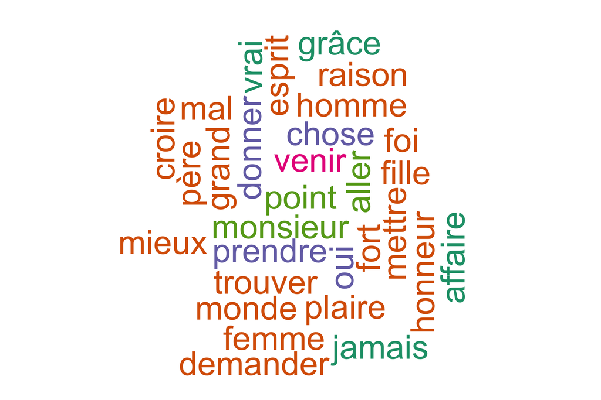

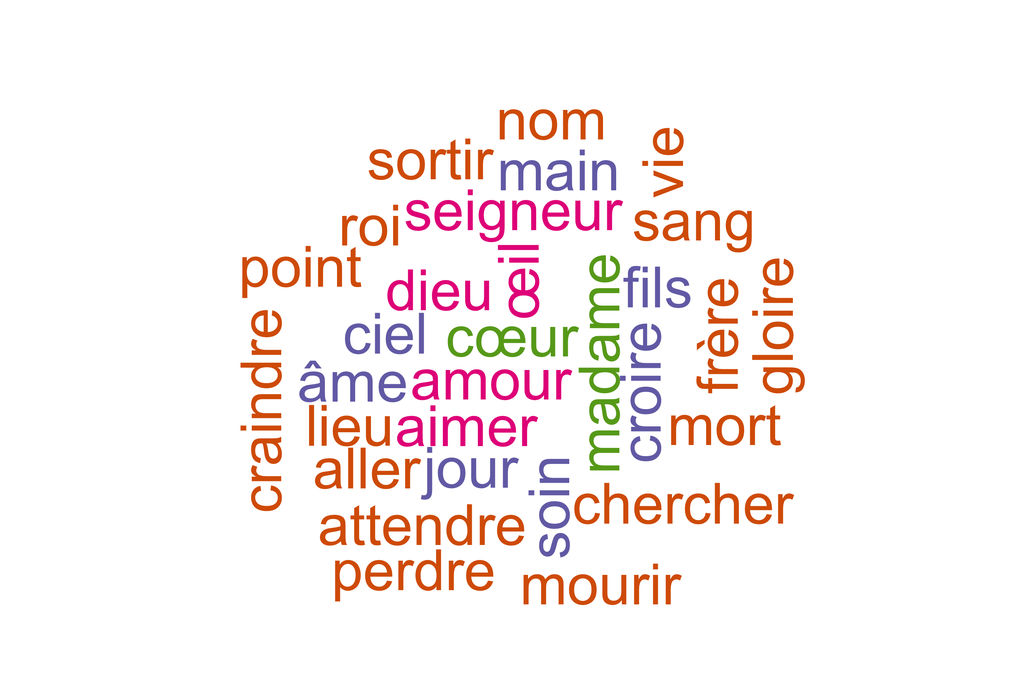

```r
for(topic in seq(k)){
    data$topic <-tm[topic,]
    #text(x=0.5, y=1, paste("V",topic, sep=""),cex=0.6)
    wordcloud(
      words = data$colnames.tm.,
      freq = data$topic,
      #sous ce seuil, les mots ne seront pas affichés
      min.freq=0.0002,
      #nombre maximum de mots à afficher
      max.words=30,
      #Si faux, en ordre croissant
      random.order=FALSE,
      #% de mots à 90°
      rot.per=.35,
      #taille du graph
      scale=c(10,10),
      #couleurs
      colors = brewer.pal(5, "Dark2")
      # il est possible de rentrer directement les couleurs qui nous intéressent
      #c("red", "blue", "yellow", "chartreuse", "cornflowerblue", "darkorange")
    )
}
```

Finissons avec un peu de mauvais goût, grâce au package `wordcloud2`

```r
wordcloud2(data = data,
          size=0.4,
          color= "random-light",
          backgroundColor = "pink",
          shape = 'star',
          rotateRatio=1
    )
```

[output not shown]

# Rermerciements

Les données d’entraînement ont été créées par JB Camps (ENC). Des morceaux de ce script (notamment pour le nettoyage des données) proviennent d’un cours de Mattia Egloff (UniL).